# Milestone Report

Jun Yitt Cheah

June 4, 2017

# Summary

This report aims to explore the 3 English datasets provided. The datasets are large and require long computational time to analyze using conventional personal computers. Smaller sample of the datasets are subsetted for exploratory data analysis.  
Histogram of frequently used words in the datasets is plotted. Bigrams are created to tabulate the frequency of unique token of 2 consecutive words. Links between the first word and the 2nd word of frequently observed bigrams are plotted as well for visualization purpose.  
We come to a conclusion to create trigrams or even higher order n-grams to consider for more specific possibilities and possible increase in accuracy of prediction made. Stupid Backoff Model will be used for simplicity sake, and ultimately a Shiny App will be created and it shall predict the next word as the user is typing a sentence.

## Reading the Data

```r
setwd("~/Desktop/DS 10 - Capstone/Coursera-SwiftKey/final/en_US")

con <- file("en_US.twitter.txt", "r");
us_twitter <- readLines(con); close(con)
con2 <- file("en_US.news.txt", "r");
us_news <- readLines(con2); close(con2)
con3 <- file("en_US.blogs.txt", "r");
us_blogs <- readLines(con3); close(con3)
```

## Loading relevant R packages

```r
library(dplyr); library(tidytext); library(ggplot2); library(tidyr)
library(igraph); library(ggraph)
```

## Understanding the Structure of the Data

```r
summary(us_twitter)
```

```
   Length     Class      Mode
  2360148 character character
```

```r
summary(us_news)
```

```
   Length     Class      Mode
  1010242 character character
```

```r
summary(us_blogs)
```

```
   Length     Class      Mode
   899288 character character
```

```r
summary(nchar(us_twitter))
```

```
   Min. 1st Qu.  Median    Mean 3rd Qu.    Max.
   2.00   37.00   64.00   68.68  100.00  140.00
```

```r
summary(nchar(us_news))
```

```
   Min. 1st Qu.  Median    Mean 3rd Qu.    Max.
    1.0   110.0   185.0   201.2   268.0 11384.0
```

```r
summary(nchar(us_blogs))
```

```
   Min. 1st Qu.  Median    Mean 3rd Qu.    Max.
      1      47     156     230     329   40833
```

## Sampling the Data

As a start, we sample 100,000 lines of data from the 3 datasets each for exploratory data analysis.

```r
set.seed(122)
subset1 <- sample(1:length(us_twitter))[1:100000]
subset2 <- sample(1:length(us_news))[1:100000]
subset3 <- sample(1:length(us_blogs))[1:100000]

twitter_sdf <- data_frame(line = subset1, text = us_twitter[subset1], dataType = "twitter") #sample twitter df
news_sdf <- data_frame(line = subset2, text = us_news[subset2], dataType = "news") #sample news df
blogs_sdf <- data_frame(line = subset3, text = us_blogs[subset3], dataType = "blogs") #sample blogs df

sdf <- rbind(twitter_sdf, news_sdf, blogs_sdf)
```

## Tokenization (Creating a Unigram)

First, we tokenize each row/line by breaking the text into individual token (in this case, 1 word). The *tidytext* library is used to transform the original data to a tidy text dataframe. Punctuations are removed, and all tokens are converted to lower case for easy comparison or combinations between datasets.

```r
tidy_df1 <- sdf %>% unnest_tokens(word, text)
print(tidy_df1)
```

```
## # A tibble: 8,896,713 x 3
##       line dataType        word
##      <int>    <chr>       <chr>
##  1 2135983  twitter      hahaha
##  2 2135983  twitter        that
##  3 2135983  twitter       could
##  4 2135983  twitter        have
##  5 2135983  twitter        been
##  6 2135983  twitter potentially
##  7 2135983  twitter     awkward
##  8 2135983  twitter          to
##  9 2135983  twitter     whoever
## 10 2135983  twitter          is
## # ... with 8,896,703 more rows
```

### Counting the Frequency of each Unique Word

Next, we create a unigram, where each token’s frequency will be calculated and tabulated. Currently, we treat the 3 datasets as independent, and calculate frequency of token separately for each dataset (twitter/blogs/news). Stop words (such as “the”,“of”, “to”) are removed as they are not useful for the text analysis we are doing. List of stop words we will be exluding will be extracted from *stop_words* in the *tidytext* dataset.

```r
count_df <- tidy_df1 %>% anti_join(stop_words) %>% group_by(dataType) %>% count(word, sort = T)
print(count_df)
```

```
## Source: local data frame [255,868 x 3]
## Groups: dataType [3]
##
## # A tibble: 255,868 x 3
##    dataType   word     n
##       <chr>  <chr> <int>
##  1    blogs   time 10036
##  2    blogs people  6705
##  3    blogs    day  5871
##  4     news   time  5743
##  5    blogs   love  4920
##  6    blogs   life  4649
##  7     news people  4617
##  8  twitter   love  4438
##  9    blogs   it’s  4182
## 10  twitter    day  3911
## # ... with 255,858 more rows
```

### Plot of Frequently Used Words

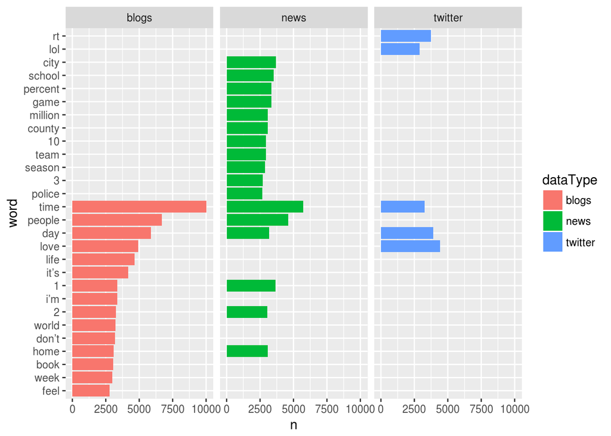

```r
cplot_df <- count_df %>% filter(n > 2500) %>% mutate(word = reorder(word, n))
ggplot(cplot_df, aes(word, n, fill = dataType)) + geom_col() + coord_flip() + facet_wrap(~dataType)
```

### Interesting Finding 1

We observed that only Twitter has words like “rt” and “lol”. We know that “lol” is usually used informally, and hence we would expect no occurence of such word in the News and Blogs datasets. We now need to investigate what is the meaning of “rt”.

```r
tidy_df1 %>% filter(word == "rt")
```

```
## # A tibble: 3,778 x 3
##       line dataType  word
##      <int>    <chr> <chr>
##  1   84419  twitter    rt
##  2   66080  twitter    rt
##  3  940724  twitter    rt
##  4  997669  twitter    rt
##  5 1739729  twitter    rt
##  6  995539  twitter    rt
##  7 1795973  twitter    rt
##  8  438468  twitter    rt
##  9  769280  twitter    rt
## 10 2163203  twitter    rt
## # ... with 3,768 more rows
```

```r
twitter_sdf %>% filter(line %in% c(84419, 66080, 940724)) %>% select(text)
```

```
## # A tibble: 3 x 1
##                                                                          text
##                                                                         <chr>
## 1                    Wasn't funny at the time, though. RT this made me laugh.
## 2 “: RT : in March sometime.--bet aye u got a new number?” naw still got the
## 3 RT : “Write it on your heart that every day is the best day in the year.” -
```

So, we subset a few lines of tweets with “rt” in it and we observed they are mostly capitalized. (I personally did not use Twitter, FB is enough to steal all my productivity away!) After some googling, I found out that RT means “Retweet” or “Real Time”. So, it makes sense, that “rt” appears frequently in the Twitter dataset.

## Creating Bigrams

Words in a sentence tend to have dependencies between each other. A n-grams consider n consecutive words as 1 token and tabulate the frequency of each unique token. A bigram, where n = 2, will consider the frequency of 2 consecutive words in the text dataset.

```r
bigram_df <- sdf %>% unnest_tokens(bigram ,text, token = "ngrams", n = 2)
print(bigram_df)
```

```
## # A tibble: 8,596,713 x 3
##     line dataType           bigram
##    <int>    <chr>            <chr>
##  1     1    blogs           in the
##  2     1    blogs        the years
##  3     1    blogs years thereafter
##  4     1    blogs  thereafter most
##  5     1    blogs          most of
##  6     1    blogs           of the
##  7     1    blogs          the oil
##  8     1    blogs       oil fields
##  9     1    blogs       fields and
## 10     1    blogs    and platforms
## # ... with 8,596,703 more rows
```

### Counting the Frequency of each Unique Bigram

```r
count_bigram_df <- bigram_df %>% count(bigram, sort = T)
print(count_bigram_df)
```

```
## # A tibble: 2,465,003 x 2
##      bigram     n
##       <chr> <int>
##  1   of the 41779
##  2   in the 37549
##  3   to the 19419
##  4   on the 17789
##  5  for the 16508
##  6    to be 14329
##  7   at the 12614
##  8  and the 12512
##  9     in a 10986
## 10 with the  9981
## # ... with 2,464,993 more rows
```

### Visualizing Dependencies of *word1* and *word2* of Bigrams

We start by separating the bigram into *word1* and *word2*. After removing the stop words, we filter out only the top few most frequent bigram and visualize it using a function provided by *Julia Silge and David Robinson* and the R package *ggraph*.

```r
sep_df <- bigram_df %>% separate(bigram, c("word1", "word2"), sep = " ")
bigram_filtered <- sep_df %>%
    filter(!word1 %in% stop_words$word) %>%
    filter(!word2 %in% stop_words$word)
bigram_count <- bigram_filtered %>% count(word1, word2, sort = T)
bigram_graph <- bigram_count %>% filter(n > 200)

print(bigram_graph)
```

```
## Source: local data frame [41 x 3]
## Groups: word1 [33]
##
## # A tibble: 41 x 3
##     word1     word2     n
##     <chr>     <chr> <int>
##  1     st     louis  1048
##  2      1         2   799
##  3    los   angeles   645
##  4    san francisco   562
##  5     30       p.m   482
##  6 health      care   471
##  7  happy  birthday   414
##  8    san     diego   392
##  9 social     media   386
## 10    ice     cream   355
## # ... with 31 more rows
```

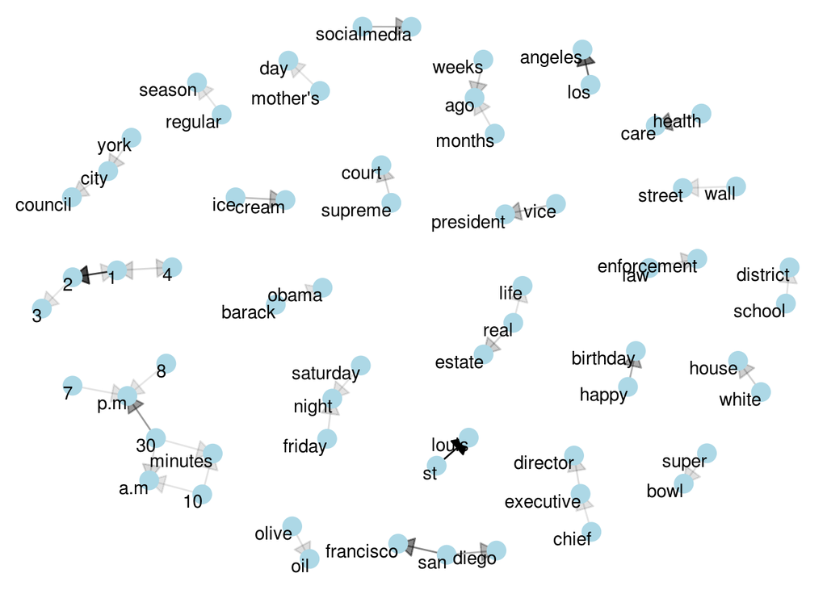

```r
visualize_bigrams <- function(bigrams) {
    set.seed(2000)
    a <- grid::arrow(type = "closed", length = unit(.15, "inches"))

    bigrams %>%
        graph_from_data_frame() %>%
        ggraph(layout = "fr") +
        geom_edge_link(aes(edge_alpha = n), show.legend = FALSE, arrow = a) +
        geom_node_point(color = "lightblue", size = 5) +
        geom_node_text(aes(label = name), vjust = 1, hjust = 1) +
        theme_void()
}

bigram_graph %>% visualize_bigrams()
```

### Interesting Finding 2

We observed a few very obvious bigrams which have very high frequency from the plot above. For example, “ice cream”, “happy birthday”, “vice president” and others. We also noticed the need to create trigrams (n = 3) and higher order n-grams, to take into consideration of words such as “chief executive director” and “york city council” which could stands for “new york city council”.

## Plans for Creating a Prediction Algorithm and Shiny App

The next step is to create a prediction algorithm based on Stupid Backoff Model, as Kantz Backoff Model is slightly more difficult to code than Stupid Backoff Model. Trigram will be created and added for better accuracy.  
Ultimately, the Shiny App shall predict the next word as the user types a sentence.